# Final Project

Systems & Technologies: Python

## The Question / Problem

You have been hired as an indepedent auditor by Colorado’s Boulder County Assessors Office to help with the following problems.

### Problem 1: Annual Report Insights (50 pts)

The Accessors Office is set to release their annual report on the valuation of residential single family properties. They have asked you to explore the data and produce at least 2 key findings they can share in their annual report to the public.

### Problem 2: Estimate Home Values (45 pts)

The Assessors Office needs help improving their valuation process for residential single family properties. They have asked you to write a KNN alogorithm to value new homes based on similar home sales. By law, residential properties must be valued by using a "market approach". This predicts the price a property would bring on the open market in a transaction between a willing, informed, and knowledgeable buyer and seller. A property can be valued through the process of analyzing comparable sales. A comparable sale is any qualified sale in the last 5 years (January 2015 - December 2020).

The central factors used by the Assessors for property valuation are:

- Location
- Living Area (SQFT)
- Age of the Home
- Finished Basement

### Problem 3: Ethics Review (5 pts)

Fairness and accuracy are vitally important. If the assessed values are too high, the property owners will overpay in taxes. If the assessed values are too low then we may fall short of the capital needed to cover the budget approved by legislators. As such, thinking through the impact of how we predict home prices is vitial.

## Problem 1: EDA for the Annual Report Insights

### Goal

Perform EDA on the property valuations for "1-Story" and "2-3 Story" single family residential buildings. Identify at least 2 key insights and/or graphs that tell a story about the valuations for these properties for the annual report.

### 1.0 Get the Data (15 pts)

Tasks:

1. Read in the following data:
   - buildings.csv
   - land.csv
   - values.csv
   - owner_addresses.csv
2. Adjust the structure of our data as necessary (joins, drop unneeded columns, add features, etc).
3. Inspect and handle missing values as necessary.

Note: These files have been pre-filtered to only include single family properties. Additionaly, in some tables columns have been dropped before sending you the data (such as owner name in owner_addresses). Complete meta data about each file can be found in the "ar-property-data-download-help.pdf" document.

#### Note :- I have seperated sections (1.0,1.1 etc) in each Problem and tasks in each section with blue lines and I have divided each Problem (1,2,3) with black lines for clarity. Also, I have seperated each plot of Univariate data and Bivariate data with brown lines.

# Problem 1: EDA for the Annual Report Insights - Solution

## 1. Get the Data

```python
# Your Code Here
import pandas as pd
import numpy as np
import seaborn as sns
import matplotlib.pyplot as plt
import warnings
warnings.filterwarnings('ignore')
```

### 1.0-1 Read in the following data:

(1). buildings.csv (2). land.csv (3). values.csv (4). owner_addresses.csv

```python
# (1). Read the buildings.csv file
buildings_df = pd.read_csv("..\\data-sets\\buildings.csv")
buildings_df.head(5)
```

|  | strap | bld_num | section_num | designCode | designCodeDscr | qualityCode | qualityCodeDscr | bldgClass | bldgClassDscr | ConstCode | ... | ExtWallDscrPrim | ExtWallSec | ExtWallDscrSec | IntWall | IntWallDscr | Roof_Cover | Roof_CoverDscr | Stories | UnitCount | status_cd |
| --- | --- | --- | --- | --- | --- | --- | --- | --- | --- | --- | --- | --- | --- | --- | --- | --- | --- | --- | --- | --- | --- |
| 0 | R0000005 | 1 | 1 | 10 | 1 Story - Ranch | 30 | AVERAGE | 1212 | SINGLE FAM RES IMPROVEMENTS | 320 | ... | Brick Veneer | NaN | NaN | 1130.0 | Drywall | 1210.0 | Asphalt | NaN | NaN | A |
| 1 | R0000006 | 1 | 1 | 20 | 2-3 Story | 32 | AVERAGE ++ | 1212 | SINGLE FAM RES IMPROVEMENTS | 310 | ... | Frame Wood/Shake | NaN | NaN | 1120.0 | Plaster | 1210.0 | Asphalt | NaN | NaN | A |
| 2 | R0000008 | 1 | 1 | 10 | 1 Story - Ranch | 31 | AVERAGE + | 1212 | SINGLE FAM RES IMPROVEMENTS | 320 | ... | Brick Veneer | NaN | NaN | 1130.0 | Drywall | 1210.0 | Asphalt | NaN | NaN | A |
| 3 | R0000009 | 1 | 1 | 10 | 1 Story - Ranch | 50 | VERY GOOD | 1212 | SINGLE FAM RES IMPROVEMENTS | 320 | ... | Moss Rock/Flagstone | 520.0 | Frame Stucco | 1130.0 | Drywall | 1290.0 | Tar and Gravel | NaN | NaN | A |
| 4 | R0000013 | 1 | 1 | 10 | 1 Story - Ranch | 50 | VERY GOOD | 1212 | SINGLE FAM RES IMPROVEMENTS | 320 | ... | Brick on Block | NaN | NaN | 1130.0 | Drywall | 1280.0 | Rubber Membrane | NaN | NaN | A |

5 rows × 42 columns

```python
buildings_df.shape
```

```
(41961, 42)
```

```python
# Explanation =
# buildings_df Data Frame has 41961 number of rows and 42 columns.
```

```python
# (2). Read the land.csv file
land_df = pd.read_csv("..\\data-sets\\land.csv")
land_df.head(5)
```

|  | strap | landUnitValue | landUnitType | landClass | landClassDscr | GIS_sqft | GIS_acreage | status_cd |
| --- | --- | --- | --- | --- | --- | --- | --- | --- |
| 0 | R0000005 | 7958.0 | SF | 1112.0 | SINGLE FAM.RES.-LAND | 7958 | 0.183 | A |
| 1 | R0000006 | 8995.0 | SF | 1112.0 | SINGLE FAM.RES.-LAND | 8995 | 0.206 | A |
| 2 | R0000008 | 6801.0 | SF | 1112.0 | SINGLE FAM.RES.-LAND | 6801 | 0.156 | A |
| 3 | R0000009 | 6308.0 | SF | 1112.0 | SINGLE FAM.RES.-LAND | 6308 | 0.145 | A |
| 4 | R0000013 | 29023.0 | SF | 1112.0 | SINGLE FAM.RES.-LAND | 29023 | 0.666 | A |

```python
# In the next couple of cells I am trying to modify the land_df so that I get the data that I want.
```

```python
land_df['landClassDscr'].unique()
```

```
array(['SINGLE FAM.RES.-LAND', 'DUP/TRIPLEXES-LAND',
       'MANUFCTD.HOUSING-LAND', nan], dtype=object)
```

```python
land_df = land_df[land_df['landClassDscr'] == 'SINGLE FAM.RES.-LAND']
```

```python
land_df['landClassDscr'].unique()
```

```
array(['SINGLE FAM.RES.-LAND'], dtype=object)
```

```python
land_df['landUnitType'].unique()
```

```
array(['SF', 'AC'], dtype=object)
```

```python
AC_indices = land_df.index[land_df['landUnitType'] == 'AC'].tolist()
AC_indices[0:5]
```

```
[6342, 6539, 6885, 6886, 6887]
```

```python
land_df[land_df.index.isin(AC_indices[0:5])]
```

|  | strap | landUnitValue | landUnitType | landClass | landClassDscr | GIS_sqft | GIS_acreage | status_cd |
| --- | --- | --- | --- | --- | --- | --- | --- | --- |
| 6342 | R0020020 | 2.1700 | AC | 1112.0 | SINGLE FAM.RES.-LAND | 92199 | 2.1166 | A |
| 6539 | R0020494 | 2.3239 | AC | 1112.0 | SINGLE FAM.RES.-LAND | 101214 | 2.3240 | A |
| 6885 | R0021536 | 5.5400 | AC | 1112.0 | SINGLE FAM.RES.-LAND | 245286 | 5.6310 | A |
| 6886 | R0021539 | 0.6684 | AC | 1112.0 | SINGLE FAM.RES.-LAND | 32846 | 0.7540 | A |
| 6887 | R0021541 | 1.1873 | AC | 1112.0 | SINGLE FAM.RES.-LAND | 56362 | 1.2939 | A |

```python
# Converting the land value in acres to square feet so that all the rows are uniform in terms of land unit type.
# 1 acre = 43560 Square Feet

for idx,row in land_df.iterrows():
    if row['landUnitType'] == 'AC':
        land_df.at[idx,'landUnitValue'] = row['landUnitValue']*43560
        land_df.at[idx,'landUnitType'] = 'SF'
```

```python
land_df[land_df.index.isin(AC_indices[0:5])]
```

|  | strap | landUnitValue | landUnitType | landClass | landClassDscr | GIS_sqft | GIS_acreage | status_cd |
| --- | --- | --- | --- | --- | --- | --- | --- | --- |
| 6342 | R0020020 | 94525.200 | SF | 1112.0 | SINGLE FAM.RES.-LAND | 92199 | 2.1166 | A |
| 6539 | R0020494 | 101229.084 | SF | 1112.0 | SINGLE FAM.RES.-LAND | 101214 | 2.3240 | A |
| 6885 | R0021536 | 241322.400 | SF | 1112.0 | SINGLE FAM.RES.-LAND | 245286 | 5.6310 | A |
| 6886 | R0021539 | 29115.504 | SF | 1112.0 | SINGLE FAM.RES.-LAND | 32846 | 0.7540 | A |
| 6887 | R0021541 | 51718.788 | SF | 1112.0 | SINGLE FAM.RES.-LAND | 56362 | 1.2939 | A |

```python
land_df['landUnitType'].unique()
```

```
array(['SF'], dtype=object)
```

```python
land_df.shape
```

```
(41937, 8)
```

```python
# Explanation =
# land_df Data Frame has 41937 number of rows and 8 columns.
```

```python
# (3). Read the values.csv file
values_df = pd.read_csv("..\\data-sets\\values.csv")
values_df.head(5)
```

|  | strap | tax_yr | bldAcutalVal | LandAcutalVal | xfActualVal | totalActualVal | landAssessedVal | bldAssessedVal | xfAssessedVal | totalAssessedVal | status_cd |
| --- | --- | --- | --- | --- | --- | --- | --- | --- | --- | --- | --- |
| 0 | R0000005 | 2021 | 73140 | 658260 | NaN | 731400 | 47066.0 | 5230.0 | NaN | 52296 | A |
| 1 | R0000006 | 2021 | 354100 | 724400 | NaN | 1078500 | 51795.0 | 25318.0 | NaN | 77113 | A |
| 2 | R0000008 | 2021 | 222700 | 668300 | NaN | 891000 | 47783.0 | 15923.0 | NaN | 63706 | A |
| 3 | R0000009 | 2021 | 719800 | 986400 | NaN | 1706200 | 70528.0 | 51466.0 | NaN | 121994 | A |
| 4 | R0000013 | 2021 | 1054300 | 783700 | NaN | 1838000 | 56035.0 | 75382.0 | NaN | 131417 | A |

```python
values_df.shape
```

```
(41961, 11)
```

```python
# Explanation =
# values_df Data Frame has 41961 number of rows and 11 columns.
```

```python
# (4). Read the owner_addresses.csv file
owner_addresses_df = pd.read_csv("..\\data-sets\\owner_address.csv")
owner_addresses_df.head(5)
```

|  | strap | str_pfx | str_num | str | str_sfx | city | sub_code | sub_dscr | section | township | range | nh | mill_levy |
| --- | --- | --- | --- | --- | --- | --- | --- | --- | --- | --- | --- | --- | --- |
| 0 | R0000005 | NaN | 3030.0 | DOVER | DR | BOULDER | 3459.0 | HIGHLAND PARK 5 - BO | 5.0 | 1S | 70.0 | 160.0 | 87.045 |
| 1 | R0000006 | NaN | 1310.0 | HAWTHORN | AVE | BOULDER | 6255.0 | PARSONS PARK - BO | 19.0 | 1N | 70.0 | 115.0 | 87.045 |
| 2 | R0000008 | NaN | 2002.0 | COLUMBINE | AVE | BOULDER | 3822.0 | INTERURBAN PARK - BO | 6.0 | 1S | 70.0 | 102.0 | 87.045 |
| 3 | R0000009 | NaN | 3100.0 | 6TH | ST | BOULDER | 5709.0 | NEWLANDS - BO | 24.0 | 1N | 71.0 | 170.0 | 87.045 |
| 4 | R0000013 | NaN | 3640.0 | 19TH | ST | BOULDER | 1227.0 | CAROLYN HEIGHTS - BO | 19.0 | 1N | 70.0 | 120.0 | 87.045 |

```python
owner_addresses_df.shape
```

```
(41961, 13)
```

```python
# Explanation =
# owner_addresses_df Data Frame has 41961 number of rows and 13 columns.
```

### 1.0-2 Adjust the structure of our data as necessary (joins, drop unneeded columns, add features, etc).

```python
all_data = land_df.merge(buildings_df,
                              how = "inner",
                              on = "strap",
                              suffixes = ('_land', '_buildings')).merge(values_df,
                                                                        how = "inner",
                                                                        on = "strap").merge(owner_addresses_df,
                                                                                            how = "inner",
                                                                                            on = "strap")
all_data.head(5)

# Explanation =
# I merged all the four data frames buildings_df,values_df, owner_addresses_df using the inner join
# into a data frame called all_data
```

|  | strap | landUnitValue | landUnitType | landClass | landClassDscr | GIS_sqft | GIS_acreage | status_cd_land | bld_num | section_num | ... | str | str_sfx | city | sub_code | sub_dscr | section | township | range | nh | mill_levy |
| --- | --- | --- | --- | --- | --- | --- | --- | --- | --- | --- | --- | --- | --- | --- | --- | --- | --- | --- | --- | --- | --- |
| 0 | R0000005 | 7958.0 | SF | 1112.0 | SINGLE FAM.RES.-LAND | 7958 | 0.183 | A | 1 | 1 | ... | DOVER | DR | BOULDER | 3459.0 | HIGHLAND PARK 5 - BO | 5.0 | 1S | 70.0 | 160.0 | 87.045 |
| 1 | R0000006 | 8995.0 | SF | 1112.0 | SINGLE FAM.RES.-LAND | 8995 | 0.206 | A | 1 | 1 | ... | HAWTHORN | AVE | BOULDER | 6255.0 | PARSONS PARK - BO | 19.0 | 1N | 70.0 | 115.0 | 87.045 |
| 2 | R0000008 | 6801.0 | SF | 1112.0 | SINGLE FAM.RES.-LAND | 6801 | 0.156 | A | 1 | 1 | ... | COLUMBINE | AVE | BOULDER | 3822.0 | INTERURBAN PARK - BO | 6.0 | 1S | 70.0 | 102.0 | 87.045 |
| 3 | R0000009 | 6308.0 | SF | 1112.0 | SINGLE FAM.RES.-LAND | 6308 | 0.145 | A | 1 | 1 | ... | 6TH | ST | BOULDER | 5709.0 | NEWLANDS - BO | 24.0 | 1N | 71.0 | 170.0 | 87.045 |
| 4 | R0000013 | 29023.0 | SF | 1112.0 | SINGLE FAM.RES.-LAND | 29023 | 0.666 | A | 1 | 1 | ... | 19TH | ST | BOULDER | 1227.0 | CAROLYN HEIGHTS - BO | 19.0 | 1N | 70.0 | 120.0 | 87.045 |

5 rows × 71 columns

```python
all_data.shape
```

```
(41937, 71)
```

```python
# Explanation =
# all_data Data Frame has 41937 number of rows and 71 columns.
```

```python
# Next, I am trying to get the columns that I want
```

```python
all_data = all_data[['strap','city','township','TotalFinishedSF',
                           'bsmtSF','bsmtType','bsmtTypeDscr','builtYear','EffectiveYear','totalActualVal',
                           'landUnitValue','nh',
                           'designCodeDscr','bldgClassDscr','qualityCodeDscr']]
# Explanation =
# I only want the above 15 columns in my all_data Data Frame for my analysis of valuation of residential single
# family properties
```

```python
all_data.head()
```

|  | strap | city | township | TotalFinishedSF | bsmtSF | bsmtType | bsmtTypeDscr | builtYear | EffectiveYear | totalActualVal | landUnitValue | nh | designCodeDscr | bldgClassDscr | qualityCodeDscr |
| --- | --- | --- | --- | --- | --- | --- | --- | --- | --- | --- | --- | --- | --- | --- | --- |
| 0 | R0000005 | BOULDER | 1S | 1282 | 988 | BWF | WALK-OUT BASEMENT FINISHED AREA | 1957 | 1957 | 731400 | 7958.0 | 160.0 | 1 Story - Ranch | SINGLE FAM RES IMPROVEMENTS | AVERAGE |
| 1 | R0000006 | BOULDER | 1N | 2130 | 0 | 0 | 0 | 1925 | 1985 | 1078500 | 8995.0 | 115.0 | 2-3 Story | SINGLE FAM RES IMPROVEMENTS | AVERAGE ++ |
| 2 | R0000008 | BOULDER | 1S | 1558 | 0 | 0 | 0 | 1954 | 1954 | 891000 | 6801.0 | 102.0 | 1 Story - Ranch | SINGLE FAM RES IMPROVEMENTS | AVERAGE + |
| 3 | R0000009 | BOULDER | 1N | 1604 | 1380 | BWF | WALK-OUT BASEMENT FINISHED AREA | 1964 | 1995 | 1706200 | 6308.0 | 170.0 | 1 Story - Ranch | SINGLE FAM RES IMPROVEMENTS | VERY GOOD |
| 4 | R0000013 | BOULDER | 1N | 3111 | 525 | BSU | SUBTERRANEAN BASEMENT UNFINISHED AREA | 1973 | 1995 | 1838000 | 29023.0 | 120.0 | 1 Story - Ranch | SINGLE FAM RES IMPROVEMENTS | VERY GOOD |

```python
# Next, I will change all my column names to lower case with underscores seperating the sub-names.
```

```python
all_data.columns = ['strap','city','township','total_finished_sqft',
                           'bsmt_sqft','bsmt_type','bsmt_type_dscr','built_year','effective_year','total_actual_val',
                     'land_unit_value', 'nh','design_code_dscr','bldg_class_dscr','quality_code_dscr']
```

```python
all_data.head()
```

|  | strap | city | township | total_finished_sqft | bsmt_sqft | bsmt_type | bsmt_type_dscr | built_year | effective_year | total_actual_val | land_unit_value | nh | design_code_dscr | bldg_class_dscr | quality_code_dscr |
| --- | --- | --- | --- | --- | --- | --- | --- | --- | --- | --- | --- | --- | --- | --- | --- |
| 0 | R0000005 | BOULDER | 1S | 1282 | 988 | BWF | WALK-OUT BASEMENT FINISHED AREA | 1957 | 1957 | 731400 | 7958.0 | 160.0 | 1 Story - Ranch | SINGLE FAM RES IMPROVEMENTS | AVERAGE |
| 1 | R0000006 | BOULDER | 1N | 2130 | 0 | 0 | 0 | 1925 | 1985 | 1078500 | 8995.0 | 115.0 | 2-3 Story | SINGLE FAM RES IMPROVEMENTS | AVERAGE ++ |
| 2 | R0000008 | BOULDER | 1S | 1558 | 0 | 0 | 0 | 1954 | 1954 | 891000 | 6801.0 | 102.0 | 1 Story - Ranch | SINGLE FAM RES IMPROVEMENTS | AVERAGE + |
| 3 | R0000009 | BOULDER | 1N | 1604 | 1380 | BWF | WALK-OUT BASEMENT FINISHED AREA | 1964 | 1995 | 1706200 | 6308.0 | 170.0 | 1 Story - Ranch | SINGLE FAM RES IMPROVEMENTS | VERY GOOD |
| 4 | R0000013 | BOULDER | 1N | 3111 | 525 | BSU | SUBTERRANEAN BASEMENT UNFINISHED AREA | 1973 | 1995 | 1838000 | 29023.0 | 120.0 | 1 Story - Ranch | SINGLE FAM RES IMPROVEMENTS | VERY GOOD |

### 1.0-3 Inspect and handle missing values as necessary.

```python
all_data.isnull().sum()
```

```
strap                  0
city                   0
township               0
total_finished_sqft    0
bsmt_sqft              0
bsmt_type              0
bsmt_type_dscr         0
built_year             0
effective_year         0
total_actual_val       0
land_unit_value        0
nh                     0
design_code_dscr       0
bldg_class_dscr        0
quality_code_dscr      0
dtype: int64
```

```python
# Explanation =
# None of the columns in all_data Data Frame has any missing data.
```

### 1.1 Explore the Data ( 35 pts)

Tasks:

- Explore the relationships in the data (univariate, bivariate, etc)
- Explore outliers
- Provide a summary of your findings.
  - Highlight at least 2 key findings and/or graphs that you feel would be interesting to share in the Annual Report to Homeowners.

### 1.1 Solution =

### 1.1-1 Explore the relationships in the data (univariate, bivariate, etc) and

### 1.1-2 Explore outliers

#### a) Univariate Data

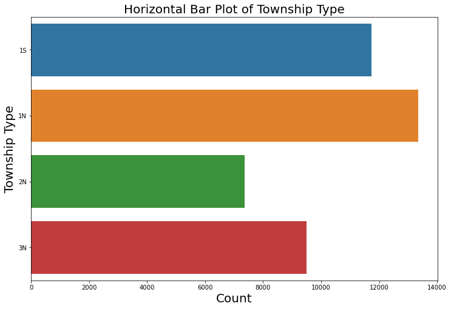

```python
# 1. Univariate Data - Categorical Data - Township
# Count Plot

fig, ax = plt.subplots(figsize=(12, 8))

sns.countplot(y = 'township', data = all_data)
ax.set_ylabel('Township Type',fontsize=20)
ax.set_xlabel('Count',fontsize=20)
ax.set_title('Horizontal Bar Plot of Township Type',fontsize=20)
```

```python
# Explanation =
# PLSS township number. Township designations indicate the location north or south of the baseline latitude.
# Each township designation is generally 6 miles north to south. Townships in Boulder County are 1S, 1N, 2N, 3N
# and are relative to the 40th parallel North (aka Baseline Rd).

# The data of residential single family properties has most houses in 1N (1 North) followed by 1S (1 South).
```

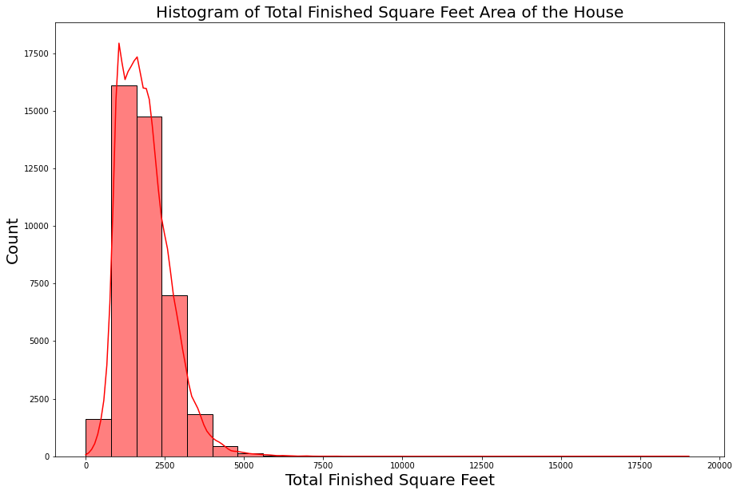

```python
# 2. Univariate Data - Continuous Data - Total Finished Square Feet
# Histogram

fig, ax = plt.subplots(figsize=(15, 10))

ax = sns.histplot(data = all_data,x = "total_finished_sqft", kde=True, color = "red", bins = 30,
                binwidth = 800)

ax.set_title('Histogram of Total Finished Square Feet Area of the House',fontsize=20)
ax.set_ylabel('Count',fontsize=20)
ax.set_xlabel('Total Finished Square Feet',fontsize=20)
```

```python
# Explanation =
# Total finished square feet – residential properties.This includes only above-grade floors
# and does not include basement sqft.

# We have more houses between 800ft to 2400 ft of total finished square feet of the house. We are not able to
# notice any outliers clearly. Lets see if we have any outliers of total_finished_sqft in our next plot.
```

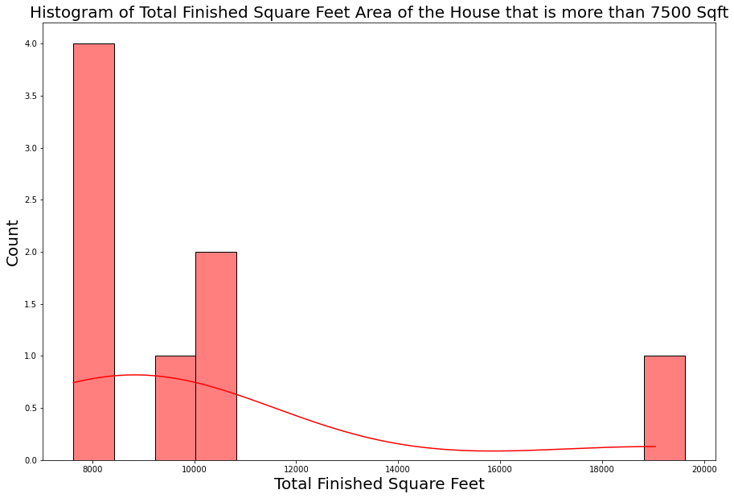

```python
# 3. Univariate Data - Continuous Data - Total Finished Square Feet > 7500 sqft
# Histogram

fig, ax = plt.subplots(figsize=(15, 10))

all_data_filt = all_data[all_data['total_finished_sqft'] > 7500]
ax = sns.histplot(data = all_data_filt,x = "total_finished_sqft", kde=True, color = "red", bins = 30,
            binwidth = 800)

ax.set_title('Histogram of Total Finished Square Feet Area of the House that is more than 7500 Sqft',fontsize=20)
ax.set_ylabel('Count',fontsize=20)
ax.set_xlabel('Total Finished Square Feet',fontsize=20)
```

```python
# Explanation =
# We do have some outliers in the total_finished_sqft which indicates that we do have some big houses
# around 8 in number, which are above 7500 total finished sqft.
```

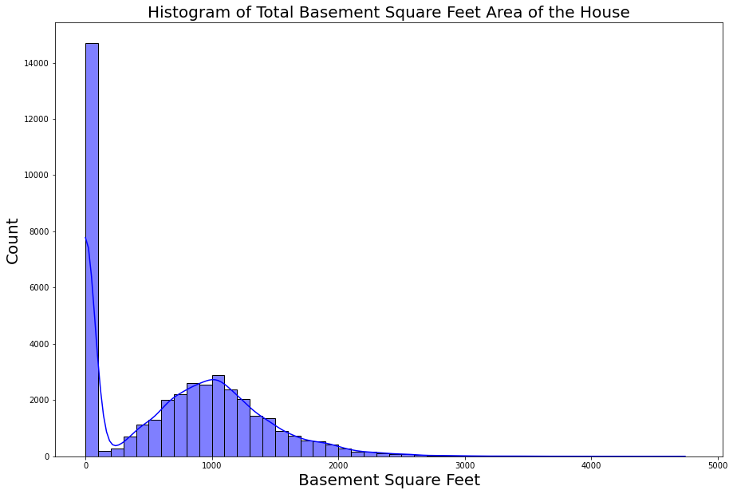

```python
# 4. Univariate Data - Continuous Data - Basement Square Feet
# Histogram

fig, ax = plt.subplots(figsize=(15, 10))

ax = sns.histplot(data = all_data,x = "bsmt_sqft", kde=True, color = "blue", bins = 30,
            binwidth = 100)

ax.set_title('Histogram of Total Basement Square Feet Area of the House',fontsize=20)
ax.set_ylabel('Count',fontsize=20)
ax.set_xlabel('Basement Square Feet',fontsize=20)
```

```python
# Explanation =
# Total basement square feet – residential properties.This includes only basement floors sqft.

# We have many residential houses without any basement floor and around 3000 houses of 1000 to 1100
# basement sqaure feet. We are not able to notice any outliers clearly. Lets see if we have any outliers of bsmt_sqft
# in our next plot.
```

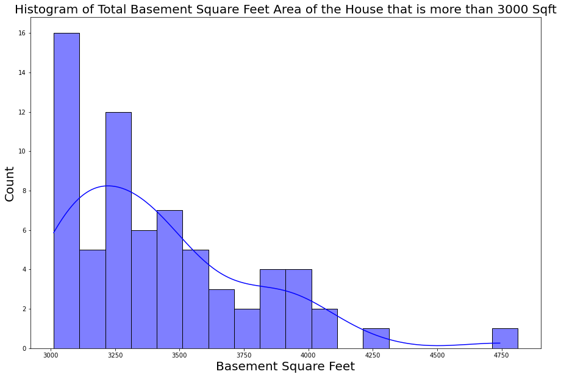

```python
# 5. Univariate Data - Continuous Data - Basement Square Feet > 3000 sqft
# Histogram

fig, ax = plt.subplots(figsize=(15, 10))

all_data_filt = all_data[all_data['bsmt_sqft'] > 3000]
ax = sns.histplot(data = all_data_filt,x = "bsmt_sqft", kde=True, color = "blue", bins = 30,
            binwidth = 100)

ax.set_title('Histogram of Total Basement Square Feet Area of the House that is more than 3000 Sqft',fontsize=20)
ax.set_ylabel('Count',fontsize=20)
ax.set_xlabel('Basement Square Feet',fontsize=20)
```

```python
# Explanation =
# We do have some outliers in the bsmt_sqft which indicates that we do have some houses with big basement
# floors, which are above 3000 basement sqft.
```